# London Bike Hire Behavioural Demand Analysis During COVID-19

# Regression Model - Eat Out to Help Out scheme - yearly basis

```r
reg_model_eotho_year <- lm(Hires ~ eat_out_to_help_out *as.factor(year), data = data)

summary(reg_model_eotho_year)
```

```
##
## Call:
## lm(formula = Hires ~ eat_out_to_help_out * as.factor(year), data = data)
##
## Residuals:
##    Min     1Q Median     3Q    Max
## -31523  -5629    133   6254  46048
##
## Coefficients: (13 not defined because of singularities)
##                                         Estimate Std. Error t value Pr(>|t|)
## (Intercept)                              14069.8      713.3  19.726  < 2e-16
## eat_out_to_help_out                       8565.0     1746.3   4.905 9.66e-07
## as.factor(year)2011                       5498.6      851.3   6.459 1.16e-10
## as.factor(year)2012                      11939.2      851.0  14.030  < 2e-16
## as.factor(year)2013                       7972.6      851.3   9.365  < 2e-16
## as.factor(year)2014                      13393.0      851.3  15.732  < 2e-16
## as.factor(year)2015                      12976.4      851.3  15.242  < 2e-16
## as.factor(year)2016                      14082.3      851.0  16.548  < 2e-16
## as.factor(year)2017                      14549.5      851.3  17.090  < 2e-16
## as.factor(year)2018                      14882.4      851.3  17.481  < 2e-16
## as.factor(year)2019                      14491.8      851.3  17.022  < 2e-16
## as.factor(year)2020                      13783.6      861.4  16.001  < 2e-16
## as.factor(year)2021                      15892.8      851.0  18.676  < 2e-16
## as.factor(year)2022                      17453.2      851.3  20.501  < 2e-16
## as.factor(year)2023                      10114.3      893.1  11.325  < 2e-16
## eat_out_to_help_out:as.factor(year)2011       NA         NA      NA       NA
## eat_out_to_help_out:as.factor(year)2012       NA         NA      NA       NA
## eat_out_to_help_out:as.factor(year)2013       NA         NA      NA       NA
## eat_out_to_help_out:as.factor(year)2014       NA         NA      NA       NA
## eat_out_to_help_out:as.factor(year)2015       NA         NA      NA       NA
## eat_out_to_help_out:as.factor(year)2016       NA         NA      NA       NA
## eat_out_to_help_out:as.factor(year)2017       NA         NA      NA       NA
## eat_out_to_help_out:as.factor(year)2018       NA         NA      NA       NA
## eat_out_to_help_out:as.factor(year)2019       NA         NA      NA       NA
## eat_out_to_help_out:as.factor(year)2020       NA         NA      NA       NA
## eat_out_to_help_out:as.factor(year)2021       NA         NA      NA       NA
## eat_out_to_help_out:as.factor(year)2022       NA         NA      NA       NA
## eat_out_to_help_out:as.factor(year)2023       NA         NA      NA       NA
##
## (Intercept)                             ***
```

[output cut: 18 more lines]

```
## eat_out_to_help_out:as.factor(year)2015
## eat_out_to_help_out:as.factor(year)2016
## eat_out_to_help_out:as.factor(year)2017
## eat_out_to_help_out:as.factor(year)2018
## eat_out_to_help_out:as.factor(year)2019
## eat_out_to_help_out:as.factor(year)2020
## eat_out_to_help_out:as.factor(year)2021
## eat_out_to_help_out:as.factor(year)2022
## eat_out_to_help_out:as.factor(year)2023
## ---
## Signif. codes:  0 '***' 0.001 '**' 0.01 '*' 0.05 '.' 0.1 ' ' 1
##
## Residual standard error: 8880 on 4797 degrees of freedom
## Multiple R-squared:  0.1637, Adjusted R-squared:  0.1613
## F-statistic: 67.07 on 14 and 4797 DF,  p-value: < 2.2e-16
```

```r
cbind(coef(reg_model_eotho_year), confint(reg_model_eotho_year))
```

```
##                                                       2.5 %    97.5 %
## (Intercept)                             14069.761 12671.460 15468.063
## eat_out_to_help_out                      8565.023  5141.527 11988.520
## as.factor(year)2011                      5498.592  3829.593  7167.591
## as.factor(year)2012                     11939.209 10270.889 13607.528
## as.factor(year)2013                      7972.592  6303.593  9641.591
## as.factor(year)2014                     13392.970 11723.971 15061.969
## as.factor(year)2015                     12976.373 11307.374 14645.372
## as.factor(year)2016                     14082.252 12413.933 15750.572
## as.factor(year)2017                     14549.537 12880.538 16218.536
## as.factor(year)2018                     14882.403 13213.404 16551.402
## as.factor(year)2019                     14491.759 12822.760 16160.758
## as.factor(year)2020                     13783.644 12094.892 15472.396
## as.factor(year)2021                     15892.845 14224.526 17561.165
## as.factor(year)2022                     17453.176 15784.177 19122.175
## as.factor(year)2023                     10114.330  8363.511 11865.150
## eat_out_to_help_out:as.factor(year)2011        NA        NA        NA
## eat_out_to_help_out:as.factor(year)2012        NA        NA        NA
## eat_out_to_help_out:as.factor(year)2013        NA        NA        NA
## eat_out_to_help_out:as.factor(year)2014        NA        NA        NA
## eat_out_to_help_out:as.factor(year)2015        NA        NA        NA
## eat_out_to_help_out:as.factor(year)2016        NA        NA        NA
## eat_out_to_help_out:as.factor(year)2017        NA        NA        NA
## eat_out_to_help_out:as.factor(year)2018        NA        NA        NA
## eat_out_to_help_out:as.factor(year)2019        NA        NA        NA
## eat_out_to_help_out:as.factor(year)2020        NA        NA        NA
## eat_out_to_help_out:as.factor(year)2021        NA        NA        NA
## eat_out_to_help_out:as.factor(year)2022        NA        NA        NA
## eat_out_to_help_out:as.factor(year)2023        NA        NA        NA
```

# Regression Model - Eat Out to Help Out scheme - monthly basis

```r
reg_model_eotho_month <- lm(Hires ~ eat_out_to_help_out *as.character(month), data = data)

summary(reg_model_eotho_month)
```

```
##
## Call:
## lm(formula = Hires ~ eat_out_to_help_out * as.character(month),
##     data = data)
##
## Residuals:
##    Min     1Q Median     3Q    Max
## -30648  -5147    452   5458  39448
##
## Coefficients: (11 not defined because of singularities)
##                                            Estimate Std. Error t value Pr(>|t|)
## (Intercept)                                 26242.0      395.2  66.410  < 2e-16
## eat_out_to_help_out                          5145.6     1524.7   3.375 0.000745
## as.character(month)Aug                       5030.8      553.3   9.092  < 2e-16
## as.character(month)Dec                      -9005.8      554.0 -16.257  < 2e-16
## as.character(month)Feb                      -5871.9      567.5 -10.347  < 2e-16
## as.character(month)Jan                      -7541.5      554.3 -13.605  < 2e-16
## as.character(month)Jul                       8918.6      553.6  16.109  < 2e-16
## as.character(month)Jun                       7502.1      558.8  13.425  < 2e-16
## as.character(month)Mar                      -3390.6      554.3  -6.117 1.03e-09
## as.character(month)May                       4480.2      554.3   8.083 7.96e-16
## as.character(month)Nov                      -2920.1      558.8  -5.225 1.81e-07
## as.character(month)Oct                       1425.2      554.3   2.571 0.010166
## as.character(month)Sep                       4405.8      548.8   8.029 1.23e-15
## eat_out_to_help_out:as.character(month)Aug       NA         NA      NA       NA
## eat_out_to_help_out:as.character(month)Dec       NA         NA      NA       NA
## eat_out_to_help_out:as.character(month)Feb       NA         NA      NA       NA
## eat_out_to_help_out:as.character(month)Jan       NA         NA      NA       NA
## eat_out_to_help_out:as.character(month)Jul       NA         NA      NA       NA
## eat_out_to_help_out:as.character(month)Jun       NA         NA      NA       NA
## eat_out_to_help_out:as.character(month)Mar       NA         NA      NA       NA
## eat_out_to_help_out:as.character(month)May       NA         NA      NA       NA
## eat_out_to_help_out:as.character(month)Nov       NA         NA      NA       NA
## eat_out_to_help_out:as.character(month)Oct       NA         NA      NA       NA
## eat_out_to_help_out:as.character(month)Sep       NA         NA      NA       NA
##
## (Intercept)                                ***
## eat_out_to_help_out                        ***
## as.character(month)Aug                     ***
## as.character(month)Dec                     ***
```

[output cut: 11 more lines]

```
## eat_out_to_help_out:as.character(month)Feb
## eat_out_to_help_out:as.character(month)Jan
## eat_out_to_help_out:as.character(month)Jul
## eat_out_to_help_out:as.character(month)Jun
## eat_out_to_help_out:as.character(month)Mar
## eat_out_to_help_out:as.character(month)May
## eat_out_to_help_out:as.character(month)Nov
## eat_out_to_help_out:as.character(month)Oct
## eat_out_to_help_out:as.character(month)Sep
## ---
## Signif. codes:  0 '***' 0.001 '**' 0.01 '*' 0.05 '.' 0.1 ' ' 1
##
## Residual standard error: 7804 on 4799 degrees of freedom
## Multiple R-squared:  0.3539, Adjusted R-squared:  0.3523
## F-statistic:   219 on 12 and 4799 DF,  p-value: < 2.2e-16
```

```r
cbind(coef(reg_model_eotho_month), confint(reg_model_eotho_month))
```

```
##                                                            2.5 %    97.5 %
## (Intercept)                                26242.038  25467.3618 27016.715
## eat_out_to_help_out                         5145.613   2156.4090  8134.818
## as.character(month)Aug                      5030.777   3946.0660  6115.488
## as.character(month)Dec                     -9005.771 -10091.7967 -7919.746
## as.character(month)Feb                     -5871.864  -6984.4546 -4759.274
## as.character(month)Jan                     -7541.455  -8628.1425 -6454.768
## as.character(month)Jul                      8918.641   7833.2738 10004.007
## as.character(month)Jun                      7502.064   6406.5059  8597.622
## as.character(month)Mar                     -3390.582  -4477.2691 -2303.895
## as.character(month)May                      4480.160   3393.4729  5566.847
## as.character(month)Nov                     -2920.074  -4015.6326 -1824.516
## as.character(month)Oct                      1425.192    338.5051  2511.879
## as.character(month)Sep                      4405.802   3329.9852  5481.619
## eat_out_to_help_out:as.character(month)Aug        NA          NA        NA
## eat_out_to_help_out:as.character(month)Dec        NA          NA        NA
## eat_out_to_help_out:as.character(month)Feb        NA          NA        NA
## eat_out_to_help_out:as.character(month)Jan        NA          NA        NA
## eat_out_to_help_out:as.character(month)Jul        NA          NA        NA
## eat_out_to_help_out:as.character(month)Jun        NA          NA        NA
## eat_out_to_help_out:as.character(month)Mar        NA          NA        NA
## eat_out_to_help_out:as.character(month)May        NA          NA        NA
## eat_out_to_help_out:as.character(month)Nov        NA          NA        NA
## eat_out_to_help_out:as.character(month)Oct        NA          NA        NA
## eat_out_to_help_out:as.character(month)Sep        NA          NA        NA
```

# Regression Model - Eat Out to Help Out scheme - daily basis

```r
reg_model_eotho_day <- lm(Hires ~ eat_out_to_help_out *as.character(day), data = data)

summary(reg_model_eotho_day)
```

```
##
## Call:
## lm(formula = Hires ~ eat_out_to_help_out * as.character(day),
##     data = data)
##
## Residuals:
##    Min     1Q Median     3Q    Max
## -24615  -6668   -606   6591  45690
##
## Coefficients:
##                                          Estimate Std. Error t value Pr(>|t|)
## (Intercept)                              27287.02     360.88  75.613   <2e-16
## eat_out_to_help_out                       6943.73    4732.84   1.467   0.1424
## as.character(day)Mon                     -1058.67     510.35  -2.074   0.0381
## as.character(day)Sat                     -2806.95     510.35  -5.500    4e-08
## as.character(day)Sun                     -4804.25     510.54  -9.410   <2e-16
## as.character(day)Thu                      1213.31     510.54   2.377   0.0175
## as.character(day)Tue                      1091.25     510.54   2.137   0.0326
## as.character(day)Wed                      1208.03     510.54   2.366   0.0180
## eat_out_to_help_out:as.character(day)Mon  1972.67    6693.24   0.295   0.7682
## eat_out_to_help_out:as.character(day)Sat  6624.20    6693.24   0.990   0.3224
## eat_out_to_help_out:as.character(day)Sun  8049.25    6693.26   1.203   0.2292
## eat_out_to_help_out:as.character(day)Thu    89.69    6693.26   0.013   0.9893
## eat_out_to_help_out:as.character(day)Tue  2546.75    6693.26   0.380   0.7036
## eat_out_to_help_out:as.character(day)Wed  1188.47    6693.26   0.178   0.8591
##
## (Intercept)                              ***
## eat_out_to_help_out
## as.character(day)Mon                     *
## as.character(day)Sat                     ***
## as.character(day)Sun                     ***
## as.character(day)Thu                     *
## as.character(day)Tue                     *
## as.character(day)Wed                     *
## eat_out_to_help_out:as.character(day)Mon
## eat_out_to_help_out:as.character(day)Sat
## eat_out_to_help_out:as.character(day)Sun
## eat_out_to_help_out:as.character(day)Thu
## eat_out_to_help_out:as.character(day)Tue
## eat_out_to_help_out:as.character(day)Wed
## ---
## Signif. codes:  0 '***' 0.001 '**' 0.01 '*' 0.05 '.' 0.1 ' ' 1
##
## Residual standard error: 9438 on 4798 degrees of freedom
## Multiple R-squared:  0.05505,    Adjusted R-squared:  0.05249
## F-statistic:  21.5 on 13 and 4798 DF,  p-value: < 2.2e-16
```

```r
cbind(coef(reg_model_eotho_day), confint(reg_model_eotho_day))
```

```
##                                                             2.5 %      97.5 %
## (Intercept)                              27287.01754  26579.53627 27994.49882
## eat_out_to_help_out                       6943.73246  -2334.79752 16222.26243
## as.character(day)Mon                     -1058.67105  -2059.20067   -58.14143
## as.character(day)Sat                     -2806.94591  -3807.47553 -1806.41629
## as.character(day)Sun                     -4804.24595  -5805.14173 -3803.35017
## as.character(day)Thu                      1213.30749    212.41171  2214.20327
## as.character(day)Tue                      1091.25039     90.35461  2092.14617
## as.character(day)Wed                      1208.03370    207.13792  2208.92948
## eat_out_to_help_out:as.character(day)Mon  1972.67105 -11149.15188 15094.49399
## eat_out_to_help_out:as.character(day)Sat  6624.19591  -6497.62703 19746.01884
## eat_out_to_help_out:as.character(day)Sun  8049.24595  -5072.60491 21171.09681
## eat_out_to_help_out:as.character(day)Thu    89.69251 -13032.15835 13211.54336
## eat_out_to_help_out:as.character(day)Tue  2546.74961 -10575.10125 15668.60047
## eat_out_to_help_out:as.character(day)Wed  1188.46630 -11933.38456 14310.31716
```

Inference : It can be inferred from the above output that when eat out to help out increases the number of hired bikes increases by 9868.5 which is the Coefficient of eat out to help out and this can be said with 95 % confidence that this effect lies between 6276 and 13460. From significant codes it can be inferred that eat out to help out has some amount of effect on hired bikes. The variations between the actual and anticipated values of “Hires” are known as residuals. The minimum, first quartile (1Q), median, third quartile (3Q), and maximum residuals are given in the summary. The smaller p value concludes that the model is performing well and the relation between eat out to help out and hires is statistically significant. The regression model for yearly basis has coefficient of eat out to help out is positive which means that increase in participation to this scheme would increase the number of hires Similarly, the regression model for monthly and daily basis has coefficient positive which means that increase in participation would increase the number of hires. The R squared value for year and month shows that when they are considered, the model can be demonstrated clearly

# Regression Model - Rule of 6 Indoors

```r
reg_model_ro6i <- lm(Hires ~ rule_of_6_indoors , data = data)

summary(reg_model_ro6i)
```

```
##
## Call:
## lm(formula = Hires ~ rule_of_6_indoors, data = data)
##
## Residuals:
##    Min     1Q Median     3Q    Max
## -26952  -6794   -251   6808  46672
##
## Coefficients:
##                   Estimate Std. Error t value Pr(>|t|)
## (Intercept)        26421.6      139.9 188.824   <2e-16 ***
## rule_of_6_indoors   9309.7      990.7   9.397   <2e-16 ***
## ---
## Signif. codes:  0 '***' 0.001 '**' 0.01 '*' 0.05 '.' 0.1 ' ' 1
##
## Residual standard error: 9609 on 4810 degrees of freedom
## Multiple R-squared:  0.01803,    Adjusted R-squared:  0.01782
## F-statistic: 88.31 on 1 and 4810 DF,  p-value: < 2.2e-16
```

```r
cbind(coef(reg_model_ro6i), confint(reg_model_ro6i))
```

```
##                                 2.5 %   97.5 %
## (Intercept)       26421.612 26147.292 26695.93
## rule_of_6_indoors  9309.658  7367.494 11251.82
```

# Regression Model - Rule of 6 Indoors - yearly basis

```r
reg_model_ro6i_year <- lm(Hires ~ rule_of_6_indoors *as.factor(year), data = data)

summary(reg_model_ro6i_year)
```

```
##
## Call:
## lm(formula = Hires ~ rule_of_6_indoors * as.factor(year), data = data)
##
## Residuals:
##    Min     1Q Median     3Q    Max
## -31523  -5643    155   6255  46048
##
## Coefficients: (12 not defined because of singularities)
##                                       Estimate Std. Error t value Pr(>|t|)
## (Intercept)                            14069.8      710.5  19.802  < 2e-16 ***
## rule_of_6_indoors                       9123.9     1224.9   7.449 1.11e-13 ***
## as.factor(year)2011                     5498.6      848.1   6.484 9.85e-11 ***
## as.factor(year)2012                    11939.2      847.7  14.084  < 2e-16 ***
## as.factor(year)2013                     7972.6      848.1   9.401  < 2e-16 ***
## as.factor(year)2014                    13393.0      848.1  15.792  < 2e-16 ***
## as.factor(year)2015                    12976.4      848.1  15.301  < 2e-16 ***
## as.factor(year)2016                    14082.3      847.7  16.612  < 2e-16 ***
## as.factor(year)2017                    14549.5      848.1  17.156  < 2e-16 ***
## as.factor(year)2018                    14882.4      848.1  17.549  < 2e-16 ***
## as.factor(year)2019                    14491.8      848.1  17.088  < 2e-16 ***
## as.factor(year)2020                    14060.8      860.1  16.347  < 2e-16 ***
## as.factor(year)2021                    14322.3      873.5  16.396  < 2e-16 ***
## as.factor(year)2022                    17453.2      848.1  20.580  < 2e-16 ***
## as.factor(year)2023                    10114.3      889.6  11.369  < 2e-16 ***
## rule_of_6_indoors:as.factor(year)2011       NA         NA      NA       NA
## rule_of_6_indoors:as.factor(year)2012       NA         NA      NA       NA
## rule_of_6_indoors:as.factor(year)2013       NA         NA      NA       NA
## rule_of_6_indoors:as.factor(year)2014       NA         NA      NA       NA
## rule_of_6_indoors:as.factor(year)2015       NA         NA      NA       NA
## rule_of_6_indoors:as.factor(year)2016       NA         NA      NA       NA
## rule_of_6_indoors:as.factor(year)2017       NA         NA      NA       NA
## rule_of_6_indoors:as.factor(year)2018       NA         NA      NA       NA
## rule_of_6_indoors:as.factor(year)2019       NA         NA      NA       NA
## rule_of_6_indoors:as.factor(year)2020  -4930.4     2026.4  -2.433    0.015 *
## rule_of_6_indoors:as.factor(year)2021       NA         NA      NA       NA
## rule_of_6_indoors:as.factor(year)2022       NA         NA      NA       NA
## rule_of_6_indoors:as.factor(year)2023       NA         NA      NA       NA
## ---
## Signif. codes:  0 '***' 0.001 '**' 0.01 '*' 0.05 '.' 0.1 ' ' 1
##
## Residual standard error: 8846 on 4796 degrees of freedom
## Multiple R-squared:  0.1703, Adjusted R-squared:  0.1677
## F-statistic: 65.61 on 15 and 4796 DF,  p-value: < 2.2e-16
```

```r
cbind(coef(reg_model_ro6i_year), confint(reg_model_ro6i_year))
```

```
##                                                     2.5 %     97.5 %
## (Intercept)                           14069.761 12676.820 15462.7025
## rule_of_6_indoors                      9123.920  6722.614 11525.2266
## as.factor(year)2011                    5498.592  3835.991  7161.1931
## as.factor(year)2012                   11939.209 10277.285 13601.1324
## as.factor(year)2013                    7972.592  6309.991  9635.1931
## as.factor(year)2014                   13392.970 11730.369 15055.5712
## as.factor(year)2015                   12976.373 11313.772 14638.9739
## as.factor(year)2016                   14082.252 12420.329 15744.1761
## as.factor(year)2017                   14549.537 12886.936 16212.1383
## as.factor(year)2018                   14882.403 13219.802 16545.0040
## as.factor(year)2019                   14491.759 12829.158 16154.3602
## as.factor(year)2020                   14060.791 12374.547 15747.0359
## as.factor(year)2021                   14322.334 12609.781 16034.8882
## as.factor(year)2022                   17453.176 15790.575 19115.7766
## as.factor(year)2023                   10114.330  8370.222 11858.4382
## rule_of_6_indoors:as.factor(year)2011        NA        NA         NA
## rule_of_6_indoors:as.factor(year)2012        NA        NA         NA
## rule_of_6_indoors:as.factor(year)2013        NA        NA         NA
## rule_of_6_indoors:as.factor(year)2014        NA        NA         NA
## rule_of_6_indoors:as.factor(year)2015        NA        NA         NA
## rule_of_6_indoors:as.factor(year)2016        NA        NA         NA
## rule_of_6_indoors:as.factor(year)2017        NA        NA         NA
## rule_of_6_indoors:as.factor(year)2018        NA        NA         NA
## rule_of_6_indoors:as.factor(year)2019        NA        NA         NA
## rule_of_6_indoors:as.factor(year)2020 -4930.442 -8903.208  -957.6765
## rule_of_6_indoors:as.factor(year)2021        NA        NA         NA
## rule_of_6_indoors:as.factor(year)2022        NA        NA         NA
## rule_of_6_indoors:as.factor(year)2023        NA        NA         NA
```

# Regression Model - Rule of 6 Indoors - monthly basis

```r
reg_model_ro6i_month <- lm(Hires ~ rule_of_6_indoors *as.character(month), data = data)

summary(reg_model_ro6i_month)
```

```
##
## Call:
## lm(formula = Hires ~ rule_of_6_indoors * as.character(month),
##     data = data)
##
## Residuals:
##    Min     1Q Median     3Q    Max
## -30364  -5114    436   5458  39507
##
## Coefficients: (7 not defined because of singularities)
##                                          Estimate Std. Error t value Pr(>|t|)
## (Intercept)                               26242.0      394.3  66.547  < 2e-16
## rule_of_6_indoors                          7009.0     1928.2   3.635 0.000281
## as.character(month)Aug                     5362.8      543.4   9.870  < 2e-16
## as.character(month)Dec                    -9005.8      552.8 -16.290  < 2e-16
## as.character(month)Feb                    -5871.9      566.3 -10.368  < 2e-16
## as.character(month)Jan                    -7541.5      553.2 -13.633  < 2e-16
## as.character(month)Jul                     8755.4      558.8  15.670  < 2e-16
## as.character(month)Jun                     7026.2      569.2  12.344  < 2e-16
## as.character(month)Mar                    -3390.6      553.2  -6.129 9.52e-10
## as.character(month)May                     4420.9      558.4   7.917 3.00e-15
## as.character(month)Nov                    -2920.1      557.7  -5.236 1.71e-07
## as.character(month)Oct                     1454.5      558.8   2.603 0.009269
## as.character(month)Sep                     4122.1      553.2   7.452 1.09e-13
## rule_of_6_indoors:as.character(month)Aug       NA         NA      NA       NA
## rule_of_6_indoors:as.character(month)Dec       NA         NA      NA       NA
## rule_of_6_indoors:as.character(month)Feb       NA         NA      NA       NA
## rule_of_6_indoors:as.character(month)Jan       NA         NA      NA       NA
## rule_of_6_indoors:as.character(month)Jul  -3337.2     2691.4  -1.240 0.215062
## rule_of_6_indoors:as.character(month)Jun   -822.8     2430.6  -0.339 0.734987
## rule_of_6_indoors:as.character(month)Mar       NA         NA      NA       NA
## rule_of_6_indoors:as.character(month)May  -5416.8     2813.8  -1.925 0.054273
## rule_of_6_indoors:as.character(month)Nov       NA         NA      NA       NA
## rule_of_6_indoors:as.character(month)Oct  -7746.2     2768.6  -2.798 0.005164
## rule_of_6_indoors:as.character(month)Sep       NA         NA      NA       NA
##
## (Intercept)                              ***
## rule_of_6_indoors                        ***
## as.character(month)Aug                   ***
## as.character(month)Dec                   ***
```

[output cut: 11 more lines]

```
## rule_of_6_indoors:as.character(month)Feb
## rule_of_6_indoors:as.character(month)Jan
## rule_of_6_indoors:as.character(month)Jul
## rule_of_6_indoors:as.character(month)Jun
## rule_of_6_indoors:as.character(month)Mar
## rule_of_6_indoors:as.character(month)May .
## rule_of_6_indoors:as.character(month)Nov
## rule_of_6_indoors:as.character(month)Oct **
## rule_of_6_indoors:as.character(month)Sep
## ---
## Signif. codes:  0 '***' 0.001 '**' 0.01 '*' 0.05 '.' 0.1 ' ' 1
##
## Residual standard error: 7788 on 4795 degrees of freedom
## Multiple R-squared:  0.3571, Adjusted R-squared:  0.3549
## F-statistic: 166.4 on 16 and 4795 DF,  p-value: < 2.2e-16
```

```r
cbind(coef(reg_model_ro6i_month), confint(reg_model_ro6i_month))
```

```
##                                                           2.5 %      97.5 %
## (Intercept)                              26242.0385  25468.9562 27015.12069
## rule_of_6_indoors                         7009.0350   3228.9145 10789.15561
## as.character(month)Aug                    5362.7519   4297.5193  6427.98441
## as.character(month)Dec                   -9005.7711 -10089.5614 -7921.98084
## as.character(month)Feb                   -5871.8641  -6982.1647 -4761.56342
## as.character(month)Jan                   -7541.4553  -8625.9059 -6457.00477
## as.character(month)Jul                    8755.4473   7660.0272  9850.86745
## as.character(month)Jun                    7026.2004   5910.3523  8142.04850
## as.character(month)Mar                   -3390.5819  -4475.0324 -2306.13132
## as.character(month)May                    4420.8971   3326.1857  5515.60846
## as.character(month)Nov                   -2920.0744  -4013.3777 -1826.77099
## as.character(month)Oct                    1454.4602    359.0401  2549.88037
## as.character(month)Sep                    4122.1030   3037.6524  5206.55354
## rule_of_6_indoors:as.character(month)Aug         NA          NA          NA
## rule_of_6_indoors:as.character(month)Dec         NA          NA          NA
## rule_of_6_indoors:as.character(month)Feb         NA          NA          NA
## rule_of_6_indoors:as.character(month)Jan         NA          NA          NA
## rule_of_6_indoors:as.character(month)Jul -3337.1875  -8613.6273  1939.25230
## rule_of_6_indoors:as.character(month)Jun  -822.8073  -5587.9203  3942.30576
## rule_of_6_indoors:as.character(month)Mar         NA          NA          NA
## rule_of_6_indoors:as.character(month)May -5416.8373 -10933.0958    99.42122
## rule_of_6_indoors:as.character(month)Nov         NA          NA          NA
## rule_of_6_indoors:as.character(month)Oct -7746.2212 -13173.8790 -2318.56348
## rule_of_6_indoors:as.character(month)Sep         NA          NA          NA
```

# Regression Model - Rule of 6 Indoors - daily basis

```r
reg_model_ro6i_day <- lm(Hires ~ rule_of_6_indoors *as.character(day), data = data)

summary(reg_model_ro6i_day)
```

```
##
## Call:
## lm(formula = Hires ~ rule_of_6_indoors * as.character(day), data = data)
##
## Residuals:
##    Min     1Q Median     3Q    Max
## -26413  -6618   -635   6623  45959
##
## Coefficients:
##                                        Estimate Std. Error t value Pr(>|t|)
## (Intercept)                             27223.3      360.6  75.496  < 2e-16 ***
## rule_of_6_indoors                        5113.7     2527.8   2.023 0.043130 *
## as.character(day)Mon                    -1039.2      510.0  -2.038 0.041621 *
## as.character(day)Sat                    -3012.0      509.8  -5.909 3.69e-09 ***
## as.character(day)Sun                    -4896.7      510.0  -9.602  < 2e-16 ***
## as.character(day)Thu                     1146.8      510.1   2.248 0.024617 *
## as.character(day)Tue                     1064.9      510.1   2.088 0.036891 *
## as.character(day)Wed                     1135.9      510.1   2.227 0.026016 *
## rule_of_6_indoors:as.character(day)Mon   -393.2     3574.9  -0.110 0.912432
## rule_of_6_indoors:as.character(day)Sat  13283.5     3641.6   3.648 0.000267 ***
## rule_of_6_indoors:as.character(day)Sun   7751.2     3641.6   2.129 0.033344 *
## rule_of_6_indoors:as.character(day)Thu   3283.1     3574.9   0.918 0.358469
## rule_of_6_indoors:as.character(day)Tue   2013.8     3574.9   0.563 0.573238
## rule_of_6_indoors:as.character(day)Wed   3873.8     3574.9   1.084 0.278592
## ---
## Signif. codes:  0 '***' 0.001 '**' 0.01 '*' 0.05 '.' 0.1 ' ' 1
##
## Residual standard error: 9361 on 4798 degrees of freedom
## Multiple R-squared:  0.07033,    Adjusted R-squared:  0.06781
## F-statistic: 27.92 on 13 and 4798 DF,  p-value: < 2.2e-16
```

```r
cbind(coef(reg_model_ro6i_day), confint(reg_model_ro6i_day))
```

```
##                                                         2.5 %     97.5 %
## (Intercept)                            27223.3294 26516.40540 27930.2534
## rule_of_6_indoors                       5113.7421   158.06595 10069.4182
## as.character(day)Mon                   -1039.2018 -2038.94326   -39.4603
## as.character(day)Sat                   -3011.9960 -4011.36718 -2012.6249
## as.character(day)Sun                   -4896.7047 -5896.44622 -3896.9633
## as.character(day)Thu                    1146.8326   146.71980  2146.9454
## as.character(day)Tue                    1064.9470    64.83422  2065.0598
## as.character(day)Wed                    1135.9188   135.80598  2136.0315
## rule_of_6_indoors:as.character(day)Mon  -393.1554 -7401.53971  6615.2290
## rule_of_6_indoors:as.character(day)Sat 13283.4631  6144.31733 20422.6088
## rule_of_6_indoors:as.character(day)Sun  7751.2487   612.05111 14890.4463
## rule_of_6_indoors:as.character(day)Thu  3283.0960 -3725.34134 10291.5333
## rule_of_6_indoors:as.character(day)Tue  2013.8387 -4994.59861  9022.2760
## rule_of_6_indoors:as.character(day)Wed  3873.7955 -3134.64181 10882.2328
```

Inference : It can be inferred from the above output that when rule of 6 indoors increases the number of hired bikes increases by 9309 which is the Coefficient of eat out to help out and this can be said with 95 % confidence that this effect lies between 7367 and 11251. From significant codes it can be inferred that rule of 6 indoors scheme has some amount of effect on hired bikes. The variations between the actual and anticipated values of “Hires” are known as residuals. The minimum, first quartile (1Q), median, third quartile (3Q), and maximum residuals are given in the summary. The smaller p value concludes that the model is performing well and the relation between rule of 6 indoors and hires is statistically significant. The regression model for yearly basis has coefficient of rule of 6 indoors is positive which means that increase in participation to this scheme would increase the number of hires Similarly, the regression model for monthly and daily basis has coefficient positive which means that increase in participation would increase the number of hires. The R squared value for year and month shows that when they are considered, the model can be demonstrated clearly

# Graph : number of hired Bikes - monthly

```r
combined_data_month <- bind_rows(
  pre_data = mutate(pre_data, period = " PRE COVID"),
  during_data = mutate(during_data, period = "DURING COVID"),
  post_data = mutate(post_data, period = "POST COVID"),
  .id = "period")

monthlyhired_data <- aggregate(Hires ~ month + period , data = combined_data_month, sum)

head(monthlyhired_data)
```

```
##   month      period   Hires
## 1   Jul during_data 1170060
## 2   Aug during_data 1153276
## 3   Sep during_data 1137524
## 4   Oct during_data  848233
## 5   Nov during_data  760245
## 6   Dec during_data  589091
```

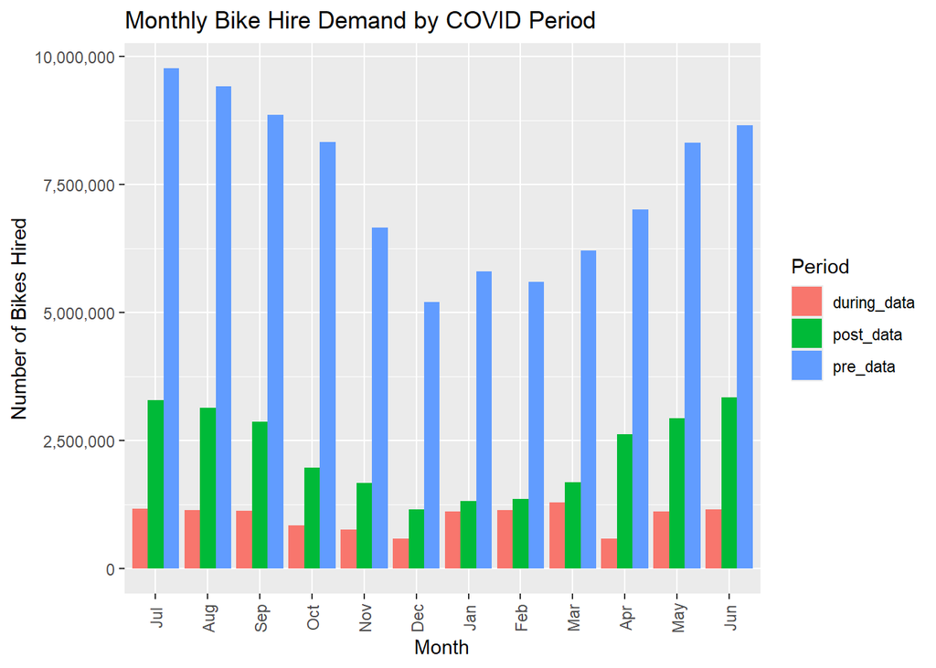

```r
g3 <- ggplot(monthlyhired_data, aes(x = month, y = Hires, fill = period)) +
  geom_col(position = "dodge") +  # Use only geom_col for bars
  labs(title = "Monthly Bike Hire Demand by COVID Period",
       x = "Month",
       y = "Number of Bikes Hired",
       fill = "Period") +
  theme(axis.text.x = element_text(angle = 90, vjust = 0.5)) +
  scale_y_continuous(labels = scales::comma)

print(g3)
```

# Graph : number of hired Bikes - Day

```r
combined_data_day <- bind_rows(
  pre_data = mutate(pre_data, period = " PRE COVID"),
  during_data = mutate(during_data, period = "DURING COVID"),
  post_data = mutate(post_data, period = "POST COVID"),
  .id = "period")

combined_data_day$Hires <- as.factor(combined_data_day$Hires)

dailyhired_data <- aggregate(Hires ~ day + period , data = combined_data_month, sum)

dailyhired_data
```

```
##    day      period    Hires
## 1  Fri during_data  1717060
## 2  Sat during_data  2029873
## 3  Sun during_data  1817333
## 4  Mon during_data  1593697
## 5  Tue during_data  1713792
## 6  Wed during_data  1638207
## 7  Thu during_data  1593649
## 8  Fri   post_data  3927065
## 9  Sat   post_data  3949628
## 10 Sun   post_data  3412205
## 11 Mon   post_data  3691640
## 12 Tue   post_data  4060959
## 13 Wed   post_data  4145140
## 14 Thu   post_data  4218362
## 15 Fri    pre_data 13379318
## 16 Sat    pre_data 11072146
## 17 Sun    pre_data 10379647
## 18 Mon    pre_data 12994167
## 19 Tue    pre_data 13975735
## 20 Wed    pre_data 14053901
## 21 Thu    pre_data 14021803
```

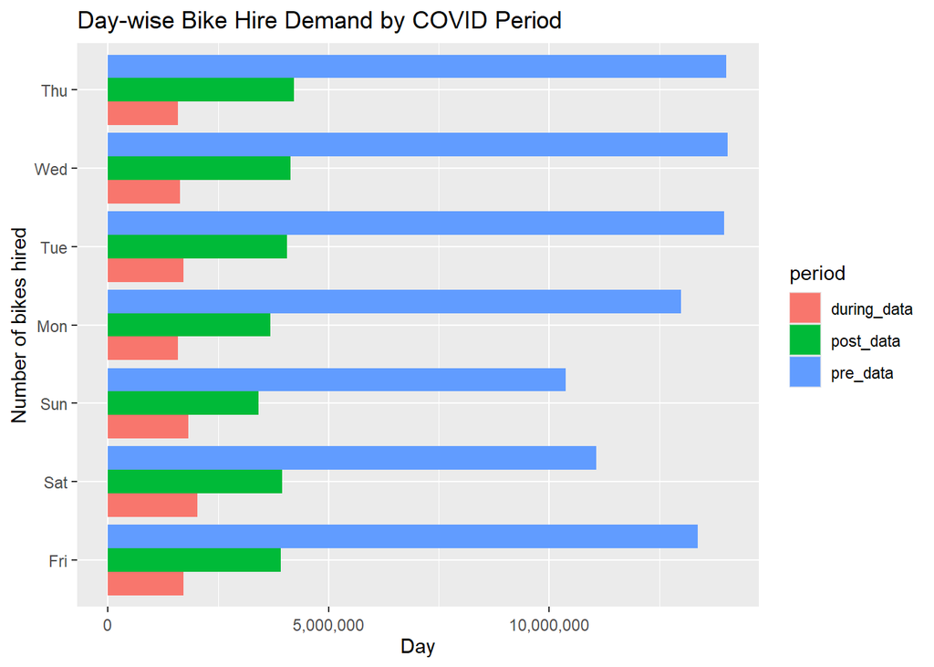

```r
g4 <- ggplot(dailyhired_data, aes(x = Hires, y = day, fill = period)) +
   geom_tile(alpha = 0.5) +
  geom_col(stat = "identity", position = "dodge") +
  labs(title = "Day-wise Bike Hire Demand by COVID Period",
          x = "Day",
       y = "Number of bikes hired" ,
       fill = "period" ) +
   theme(axis.text.x = element_text(angle = 0, vjust = 0.5))

g4 <- g4 +
  scale_x_continuous(labels = scales::comma)

print(g4)
```

# Correlation Analysis

```r
data$schools_closed <- as.numeric(data$schools_closed)
data$pubs_closed <- as.numeric(data$pubs_closed)
data$shops_closed <- as.numeric(data$shops_closed)
data$eating_places_closed <- as.numeric(data$eating_places_closed)
data$stay_at_home <- as.numeric(data$stay_at_home)
data$household_mixing_indoors_banned <-as.numeric(data$household_mixing_indoors_banned)
data$wfh <- as.numeric(data$wfh)
data$rule_of_6_indoors <- as.numeric(data$rule_of_6_indoors)
data$curfew <- as.numeric(data$curfew)
data$eat_out_to_help_out <- as.numeric(data$eat_out_to_help_out)
```

```r
#Correlation between schemes and Hires
wfh_corelation <- cor(data$Hires, data$wfh, method = "pearson")
ro6i_corelation <- cor(data$Hires, data$rule_of_6_indoors, method = "pearson")
eotho_corelation <- cor(data$Hires, data$eat_out_to_help_out, method = "pearson")
```

```r
corelation <- c(wfh = wfh_corelation, rule_of_6_indoors = ro6i_corelation,
                  eat_out_to_help_out = eotho_corelation)

print(corelation)
```

```
##                 wfh   rule_of_6_indoors eat_out_to_help_out
##          0.07647709          0.13427093          0.07741978
```

The above Correlation code is used to calculate the correlation between the number of hired bikes and three different variable schemes : WFH (work from home) scheme, Rule of 6 indoors(ro6i) and eat out to help out scheme (eotho). The output shows the correlation.

Based on the output we can infer that - - There is a weak or slight correlation of 7% between the number of hires and the WFH variable, which implies that as the number of people working from home increases the hiring of the bikes also slightly increases but this hiring is not strongly affected by the work from home scheme - There is a weak correlation of 13% between the number of hires and the ro6i variable, which implies that as the proportion of people following the rule of 6 indoors increases the hiring of the bikes also slightly increases but this hiring is not strongly affected by this scheme - There is a weak correlation of 7% between the number of hires and the eotho variable, which implies that as the number of people increases in the eat out to help out scheme the hiring of the bikes also slightly increases but this hiring is not strongly affected by this scheme

## Model Comparison Using ANOVA

# Work from home scheme

```r
anova(reg_model_wfh, reg_model_wfh_year)
```

```
## Analysis of Variance Table
##
## Model 1: Hires ~ wfh
## Model 2: Hires ~ wfh * as.factor(year)
##   Res.Df        RSS Df  Sum of Sq      F    Pr(>F)
## 1   4810 4.4965e+11
## 2   4796 3.7359e+11 14 7.6058e+10 69.743 < 2.2e-16 ***
## ---
## Signif. codes:  0 '***' 0.001 '**' 0.01 '*' 0.05 '.' 0.1 ' ' 1
```

The test suggests that the interaction between wfh scheme and year when included improves the model significantly to predict the number of hired bikes. The higher f score (69.7) implies that year variable contribute in the hiring of the bike

```r
anova(reg_model_wfh, reg_model_wfh_month)
```

```
## Analysis of Variance Table
##
## Model 1: Hires ~ wfh
## Model 2: Hires ~ wfh * as.character(month)
##   Res.Df        RSS Df  Sum of Sq      F    Pr(>F)
## 1   4810 4.4965e+11
## 2   4788 2.8799e+11 22 1.6166e+11 122.17 < 2.2e-16 ***
## ---
## Signif. codes:  0 '***' 0.001 '**' 0.01 '*' 0.05 '.' 0.1 ' ' 1
```

The test suggests that the interaction between wfh scheme and month when included improves the model significantly to predict the number of hired bikes. The higher f score (122.1) implies that month variable contribute significantly in the hiring of the bike.

```r
anova(reg_model_wfh, reg_model_wfh_day)
```

```
## Analysis of Variance Table
##
## Model 1: Hires ~ wfh
## Model 2: Hires ~ wfh * as.character(day)
##   Res.Df        RSS Df  Sum of Sq      F    Pr(>F)
## 1   4810 4.4965e+11
## 2   4798 4.2114e+11 12 2.8511e+10 27.068 < 2.2e-16 ***
## ---
## Signif. codes:  0 '***' 0.001 '**' 0.01 '*' 0.05 '.' 0.1 ' ' 1
```

The test suggests that the interaction between wfh scheme and day when included improves the model significantly to predict the number of hired bikes. The higher f score (27.06) implies that day variable contributes in the hiring of the bike. The most significantly contributing variable is the month variable and therefore should be used.

# Rule of 6 indoor scheme

```r
anova(reg_model_ro6i, reg_model_ro6i_year)
```

```
## Analysis of Variance Table
##
## Model 1: Hires ~ rule_of_6_indoors
## Model 2: Hires ~ rule_of_6_indoors * as.factor(year)
##   Res.Df        RSS Df  Sum of Sq      F    Pr(>F)
## 1   4810 4.4414e+11
## 2   4796 3.7528e+11 14 6.8857e+10 62.855 < 2.2e-16 ***
## ---
## Signif. codes:  0 '***' 0.001 '**' 0.01 '*' 0.05 '.' 0.1 ' ' 1
```

The test suggests that the interaction between rule of 6 indoors scheme and year when included improves the model significantly to predict the number of hired bikes. The higher f score (62.85) implies that year variable contributes in the hiring of the bike.

```r
anova(reg_model_ro6i, reg_model_ro6i_month)
```

```
## Analysis of Variance Table
##
## Model 1: Hires ~ rule_of_6_indoors
## Model 2: Hires ~ rule_of_6_indoors * as.character(month)
##   Res.Df        RSS Df  Sum of Sq      F    Pr(>F)
## 1   4810 4.4414e+11
## 2   4795 2.9080e+11 15 1.5335e+11 168.57 < 2.2e-16 ***
## ---
## Signif. codes:  0 '***' 0.001 '**' 0.01 '*' 0.05 '.' 0.1 ' ' 1
```

The test suggests that the interaction between ro6i scheme and month when included improves the model significantly to predict the number of hired bikes. The higher f score (168.57) implies that month variable contributes in the hiring of the bike.

```r
anova(reg_model_ro6i, reg_model_ro6i_day)
```

```
## Analysis of Variance Table
##
## Model 1: Hires ~ rule_of_6_indoors
## Model 2: Hires ~ rule_of_6_indoors * as.character(day)
##   Res.Df        RSS Df  Sum of Sq      F    Pr(>F)
## 1   4810 4.4414e+11
## 2   4798 4.2048e+11 12 2.3657e+10 22.495 < 2.2e-16 ***
## ---
## Signif. codes:  0 '***' 0.001 '**' 0.01 '*' 0.05 '.' 0.1 ' ' 1
```

The test suggests that the interaction between ro6i scheme and day when included improves the model significantly to predict the number of hired bikes. The higher f score (22.495) implies that day variable contributes in the hiring of the bike. The most significantly contributing variable is the month variable and therefore should be used.

# Eat out to help out Scheme

```r
anova(reg_model_eotho, reg_model_eotho_year)
```

```
## Analysis of Variance Table
##
## Model 1: Hires ~ eat_out_to_help_out
## Model 2: Hires ~ eat_out_to_help_out * as.factor(year)
##   Res.Df        RSS Df  Sum of Sq      F    Pr(>F)
## 1   4810 4.4959e+11
## 2   4797 3.7826e+11 13 7.1328e+10 69.582 < 2.2e-16 ***
## ---
## Signif. codes:  0 '***' 0.001 '**' 0.01 '*' 0.05 '.' 0.1 ' ' 1
```

The test suggests that the interaction between eotho scheme and year when included improves the model significantly to predict the number of hired bikes. The higher f score (69.58) implies that year variable contributes in the hiring of the bike.

```r
anova(reg_model_eotho, reg_model_eotho_month)
```

```
## Analysis of Variance Table
##
## Model 1: Hires ~ eat_out_to_help_out
## Model 2: Hires ~ eat_out_to_help_out * as.character(month)
##   Res.Df        RSS Df  Sum of Sq      F    Pr(>F)
## 1   4810 4.4959e+11
## 2   4799 2.9224e+11 11 1.5734e+11 234.89 < 2.2e-16 ***
## ---
## Signif. codes:  0 '***' 0.001 '**' 0.01 '*' 0.05 '.' 0.1 ' ' 1
```

The test suggests that the interaction between eotho scheme and month when included improves the model significantly to predict the number of hired bikes. The higher f score (234.89) implies that month variable contributes in the hiring of the bike.

```r
anova(reg_model_eotho, reg_model_eotho_day)
```

```
## Analysis of Variance Table
##
## Model 1: Hires ~ eat_out_to_help_out
## Model 2: Hires ~ eat_out_to_help_out * as.character(day)
##   Res.Df        RSS Df  Sum of Sq      F    Pr(>F)
## 1   4810 4.4959e+11
## 2   4798 4.2740e+11 12 2.2189e+10 20.758 < 2.2e-16 ***
## ---
## Signif. codes:  0 '***' 0.001 '**' 0.01 '*' 0.05 '.' 0.1 ' ' 1
```

The test suggests that the interaction between eotho scheme and day when included improves the model significantly to predict the number of hired bikes. The higher f score (20.75) implies that day variable contributes in the hiring of the bike. The most significantly contributing variable is the month variable and therefore should be used.